# Project: investigate the dataset "Medical Appointment No Shows"

- Introduction
- Data Wrangling
- Exploratory Data Analysis
- Conclusions

## Introduction

This project analyzes the dataset named "Medical Appointment No Shows". This dataset collects information from over 100k medical appointments in Brazil and is focused on the question of whether or not patients show up for their appointment. A number of characteristics about the patient are included in each row. The source of this data can be found at: [Kaggle](https://www.kaggle.com/joniarroba/noshowappointments).

One person schedules an appointment, but still does not show up. Can we understand why this happens? **(1)** Do no-shows occur more often in specific days or months. **(2)** Do no-shows occur more often in men or women, or **(3)** do they relate with a person's health status? Finally, **(4)** is social support influecing the rate of appointment no-shows?

These four questions will be investigated below with a variety of descriptive statistics and graphical representations. For this, first I will load, inspect and modify the dataset in order to clean it and prepare it for further analysis. Then I will briefly describe the nature of its variables. Further, I will calculate various descriptive measures to look at the differences between groups of interest. Ultimately, I will produce some graphical representations to answer the questions posed here. I will end my analysis with a final section summing up my conclusions on this analysis.

```python
# Required packages and magic functions for the analysis:
import numpy as np
import pandas as pd
import datetime as dt
import matplotlib.pyplot as plt
import seaborn as sns
%matplotlib inline
```

## Data Wrangling

### General Properties

```python
# Load data:
data = pd.read_csv("noshow_data.csv")

# First glance at the dataset:
print("Data dimensions (row nr., column nr.) are: ", data.shape)
data.head()
```

```
Data dimensions (row nr., column nr.) are:  (110527, 14)
```

|  | PatientId | AppointmentID | Gender | ScheduledDay | AppointmentDay | Age | Neighbourhood | Scholarship | Hipertension | Diabetes | Alcoholism | Handcap | SMS_received | No-show |
| --- | --- | --- | --- | --- | --- | --- | --- | --- | --- | --- | --- | --- | --- | --- |
| 0 | 2.987250e+13 | 5642903 | F | 2016-04-29T18:38:08Z | 2016-04-29T00:00:00Z | 62 | JARDIM DA PENHA | 0 | 1 | 0 | 0 | 0 | 0 | No |
| 1 | 5.589978e+14 | 5642503 | M | 2016-04-29T16:08:27Z | 2016-04-29T00:00:00Z | 56 | JARDIM DA PENHA | 0 | 0 | 0 | 0 | 0 | 0 | No |
| 2 | 4.262962e+12 | 5642549 | F | 2016-04-29T16:19:04Z | 2016-04-29T00:00:00Z | 62 | MATA DA PRAIA | 0 | 0 | 0 | 0 | 0 | 0 | No |
| 3 | 8.679512e+11 | 5642828 | F | 2016-04-29T17:29:31Z | 2016-04-29T00:00:00Z | 8 | PONTAL DE CAMBURI | 0 | 0 | 0 | 0 | 0 | 0 | No |
| 4 | 8.841186e+12 | 5642494 | F | 2016-04-29T16:07:23Z | 2016-04-29T00:00:00Z | 56 | JARDIM DA PENHA | 0 | 1 | 1 | 0 | 0 | 0 | No |

```python
# Look at the nature of variables and check for missing values:
data.info()
```

```
<class 'pandas.core.frame.DataFrame'>
RangeIndex: 110527 entries, 0 to 110526
Data columns (total 14 columns):
PatientId         110527 non-null float64
AppointmentID     110527 non-null int64
Gender            110527 non-null object
ScheduledDay      110527 non-null object
AppointmentDay    110527 non-null object
Age               110527 non-null int64
Neighbourhood     110527 non-null object
Scholarship       110527 non-null int64
Hipertension      110527 non-null int64
Diabetes          110527 non-null int64
Alcoholism        110527 non-null int64
Handcap           110527 non-null int64
SMS_received      110527 non-null int64
No-show           110527 non-null object
dtypes: float64(1), int64(8), object(5)
memory usage: 11.8+ MB
```

### Data description:

The data is composed of 14 variables (columns) and 110527 observations (rows).

"PatientId" and "AppointmentID" are set as numerical classes (i.e., float and int), but probably they should be analyzed as categorical variables (strings). Variables related to date ("ScheduleDay" and "AppointmentDay") are set as strings, but they should be set to datetime, in order for analysis to account for the specific time-points, not only weekdays, but maybe also months and years. "Scholarship" is of integer type ("0/1", which actually represents "no/yes"). The same is true for "Hipertension", "Diabetes", "Alcoholism", "Handcap" and "SMS_received". In order to facilitate the analysis, these variables should be edited accordingly.

However, not all variables would be interesting to use in the analysis. For example "AppointmentID" might not be informative to relate to "No-show", or the time an appointment was set, i.e., "ScheduleDay". These variables could be removed from the dataset, to spare some computing time and memory usage during the analysis.

Variable names could be edited, for better comprehension and ease of coding. "No-show" may be a tricky variable, and perhaps the opposite may be more easy for understanding the analysis. That is, whether persons did indeed go to the appointments ("attendance").

Finally, no missing values are present in this dataset. There might be duplicated rows in the data, thus it needs to be further checked and resolved.

### Data preparation:

- 1: Check for duplicates and remove them
- 2: Remove unimportant variables
- 3: Rename variable names
- 4: Correct variable class types
- 5: Create new values for dates and for successful appointments
- 6: Final check up in the data

**1: Check for duplicates and remove them**

```python
print("Number of duplicated rows:", sum(data.duplicated()))
```

```
Number of duplicated rows: 0
```

```python
# Drop those duplicated rows:
# data.drop_duplicates(keep=False, inplace=True)
```

```python
# Is there more than one observation per patient?
print("Number of unique patients:", data['PatientId'].nunique())
```

```
Number of unique patients: 62299
```

> **Note:** The number of patient IDs is about 62k. However, the number of obserations is about 110k for the whole dataset (see the dataset size at the beginning of this section). Therefore, this means that patients had more than one appointment scheduled at some point with the doctors.

**2: Remove unimportant variables (not considered in the analysis)**

```python
# Drop 'AppointmentID' Neighbourhood' and 'SMS_received'
data.drop(columns=['AppointmentID', 'Neighbourhood', 'SMS_received', 'ScheduledDay'], inplace=True)
```

**3: Rename variable names**

```python
# Original column names:
print("Original column names are:\n", data.columns)
```

```
Original column names are:
 Index(['PatientId', 'Gender', 'AppointmentDay', 'Age', 'Scholarship',
       'Hipertension', 'Diabetes', 'Alcoholism', 'Handcap', 'No-show'],
      dtype='object')
```

```python
# Place underscores in the specific variables which were named with multiple words:
data.rename(columns={'PatientId': 'patient_id', 'AppointmentDay': 'appointment_day' }, inplace=True)
```

```python
# Replace any possible space or hifen with underscores, and set all variable names to lowercase (format names):
data.rename(columns=lambda x: x.strip().lower().replace(" ", "_"), inplace=True)
data.rename(columns=lambda x: x.strip().lower().replace("-", "_"), inplace=True)
```

```python
# Confirm new column names:
print("New column names are:\n", data.columns)
```

```
New column names are:
 Index(['patient_id', 'gender', 'appointment_day', 'age', 'scholarship',
       'hipertension', 'diabetes', 'alcoholism', 'handcap', 'no_show'],
      dtype='object')
```

**4: Correct variable class types**

```python
# Set IDs as categorical variables:
data['patient_id'] = data['patient_id'].astype(str)
```

```python
# Set "0/1" variables to categorical "no/yes":
data['scholarship'] = np.where(data['scholarship']==0, 'No', 'Yes')
data['hipertension'] = np.where(data['hipertension']==0, 'No', 'Yes')
data['diabetes'] = np.where(data['diabetes']==0, 'No', 'Yes')
data['alcoholism'] = np.where(data['alcoholism']==0, 'No', 'Yes')
data['handcap'] = np.where(data['handcap']==0, 'No', 'Yes')
```

```python
# Set time variable to datetime:
data['appointment_day'] = data['appointment_day'].astype('datetime64[ns]')
```

**5: Create new values for dates and for successful appointments**

```python
# Split dates into years, months and days of the week:
data['appointment_day_year'] = data['appointment_day'].dt.year
data['appointment_day_month'] = data['appointment_day'].dt.month
data['appointment_day_day'] = data['appointment_day'].dt.weekday
```

```python
# Create a new variable, the opposite to "no_show":
data['attendance'] = np.where(data['no_show']=='Yes', "No", "Yes")
# Create it again, but as a numerical variable to allow for plotting more easily
data['attendance2'] = np.where(data['no_show']=='Yes', 0, 1)
```

**6: Final check up in the data**

```python
# check up modifications
data.info()
```

```
<class 'pandas.core.frame.DataFrame'>
RangeIndex: 110527 entries, 0 to 110526
Data columns (total 15 columns):
patient_id               110527 non-null object
gender                   110527 non-null object
appointment_day          110527 non-null datetime64[ns]
age                      110527 non-null int64
scholarship              110527 non-null object
hipertension             110527 non-null object
diabetes                 110527 non-null object
alcoholism               110527 non-null object
handcap                  110527 non-null object
no_show                  110527 non-null object
appointment_day_year     110527 non-null int64
appointment_day_month    110527 non-null int64
appointment_day_day      110527 non-null int64
attendance               110527 non-null object
attendance2              110527 non-null int32
dtypes: datetime64[ns](1), int32(1), int64(4), object(9)
memory usage: 12.2+ MB
```

## Exploratory Data Analysis

Descriptive statistics and graphical representations of the data

### Descriptive statistics

```python
# Subset observations by gender:
data_m = data.query('gender == "M"', inplace=False)
data_f = data.query('gender == "F"', inplace=False)

# Group observations by unique patients (avoid pseudo-replication):
data_patient = data.groupby('patient_id')

# Group observations by unique patients within genders:
data_patient_m = data_m.groupby('patient_id')
data_patient_f = data_f.groupby('patient_id')
```

**Summary statistics for numerical variables in the entire dataset**

```python
# Descriptive statistics for numerical variables (age and date):
print("Descriptive statistics for all patients:")
round(data_patient.mean().describe(), 1)
```

```
Descriptive statistics for all patients:
```

|  | age | appointment_day_year | appointment_day_month | appointment_day_day | attendance2 |
| --- | --- | --- | --- | --- | --- |
| count | 62299.0 | 62299.0 | 62299.0 | 62299.0 | 62299.0 |
| mean | 36.7 | 2016.0 | 5.2 | 1.9 | 0.8 |
| std | 23.5 | 0.0 | 0.4 | 1.2 | 0.4 |
| min | -1.0 | 2016.0 | 4.0 | 0.0 | 0.0 |
| 25% | 17.0 | 2016.0 | 5.0 | 1.0 | 0.7 |
| 50% | 36.0 | 2016.0 | 5.0 | 2.0 | 1.0 |
| 75% | 56.0 | 2016.0 | 5.5 | 3.0 | 1.0 |
| max | 115.0 | 2016.0 | 6.0 | 5.0 | 1.0 |

> **Note:** The description of this dataset (as shown above) is taken over unique patients (*data_patient*) and not the entire dataset (*data*). The count statistic is not really relevant here, but instead, mean, min and max, which give us an impression of the values for age and date. The high std in 'age', suggests a high variation in the age for patients.

**Summary statistics for numerical variables in the men and women dataset subsets**

```python
# Descriptive statistics for men:
print("Descriptive statistics for men:")
round(data_patient_m.mean().describe(), 1)
```

```
Descriptive statistics for men:
```

|  | age | appointment_day_year | appointment_day_month | appointment_day_day | attendance2 |
| --- | --- | --- | --- | --- | --- |
| count | 22253.0 | 22253.0 | 22253.0 | 22253.0 | 22253.0 |
| mean | 33.3 | 2016.0 | 5.2 | 1.9 | 0.8 |
| std | 24.7 | 0.0 | 0.4 | 1.2 | 0.4 |
| min | 0.0 | 2016.0 | 4.0 | 0.0 | 0.0 |
| 25% | 10.0 | 2016.0 | 5.0 | 1.0 | 0.7 |
| 50% | 32.0 | 2016.0 | 5.0 | 2.0 | 1.0 |
| 75% | 54.0 | 2016.0 | 5.5 | 3.0 | 1.0 |
| max | 100.0 | 2016.0 | 6.0 | 5.0 | 1.0 |

```python
# Descriptive statistics for women:
print("Descriptive statistics for women:")
round(data_patient_f.mean().describe(), 1)
```

```
Descriptive statistics for women:
```

|  | age | appointment_day_year | appointment_day_month | appointment_day_day | attendance2 |
| --- | --- | --- | --- | --- | --- |
| count | 40046.0 | 40046.0 | 40046.0 | 40046.0 | 40046.0 |
| mean | 38.6 | 2016.0 | 5.2 | 1.9 | 0.8 |
| std | 22.6 | 0.0 | 0.4 | 1.2 | 0.3 |
| min | -1.0 | 2016.0 | 4.0 | 0.0 | 0.0 |
| 25% | 20.0 | 2016.0 | 5.0 | 1.0 | 0.7 |
| 50% | 38.0 | 2016.0 | 5.0 | 2.0 | 1.0 |
| 75% | 56.0 | 2016.0 | 5.5 | 3.0 | 1.0 |
| max | 115.0 | 2016.0 | 6.0 | 5.0 | 1.0 |

> **Note:** Comparing the descriptive statistics for men and women (the two tables above), we can observe that for dates and attendance the measurements do not seem to differ much. Only for age, however, men are overall younger than women.

> **Note:** Appointmens were set only for Apr to Jun 2016, and not on Sundays (day 6).

**Attendance percentage by gender and date (month and weekday)**

```python
# Attendance percentage to appointments by men and women:
print("Overall percentage of attendance: {} %".format(round(data_patient['attendance2'].mean().mean()*100,2)))
print("Percentage of men that attended an appointment: {} %".format(round(data_patient_m['attendance2'].mean().mean()*100,2)))
print("Percentage of women that attended an appointment: {} %".format(round(data_patient_f['attendance2'].mean().mean()*100,2)))
```

```
Overall percentage of attendance: 80.36 %
Percentage of men that attended an appointment: 80.27 %
Percentage of women that attended an appointment: 80.4 %
```

```python
# Attendance percentage to appointments by month:
month = data.groupby('appointment_day_month')['attendance2'].mean()
```

```python
print("Attendance percentage in April: {} %".format(round(month[4]*100 ,2)))
print("Attendance percentage in May: {} %".format(round(month[5]*100 ,2)))
print("Attendance percentage in June: {} %".format(round(month[6]*100 ,2)))
```

```
Attendance percentage in April: 80.43 %
Attendance percentage in May: 79.21 %
Attendance percentage in June: 81.54 %
```

```python
# Attendance percentage to appointments by weekdays:
weekday = data.groupby('appointment_day_day')['attendance2'].mean()
```

```python
print("Attendance percentage on Mondays: {} %".format(round(weekday[0]*100 ,2)))
print("Attendance percentage on Tuesdays: {} %".format(round(weekday[1]*100 ,2)))
print("Attendance percentage on Wednesdays: {} %".format(round(weekday[2]*100 ,2)))
print("Attendance percentage on Thursdays: {} %".format(round(weekday[3]*100 ,2)))
print("Attendance percentage on Fridays: {} %".format(round(weekday[4]*100 ,2)))
print("Attendance percentage on Saturdays: {} %".format(round(weekday[5]*100 ,2)))
```

```
Attendance percentage on Mondays: 79.35 %
Attendance percentage on Tuesdays: 79.91 %
Attendance percentage on Wednesdays: 80.31 %
Attendance percentage on Thursdays: 80.65 %
Attendance percentage on Fridays: 78.77 %
Attendance percentage on Saturdays: 76.92 %
```

**Cumulative proportion of attendances by gender and date**

```python
# Proportion of cumulative attendances by men and women
print("Total number of attendances: ", sum(data['attendance2']))
print("Proportion of men patients: ", round(sum(data_m['attendance2'])/sum(data['attendance2']),2))
print("Proportion of women patients:" ,round(sum(data_f['attendance2'])/sum(data['attendance2']),2))
```

```
Total number of attendances:  88208
Proportion of men patients:  0.35
Proportion of women patients: 0.65
```

```python
# Proportion of cumulative attendances by weekdays
weekday = data.groupby('appointment_day_day')['attendance2'].sum()

print("Proportion attendances on Mondays: ", round(weekday[0]/sum(data['attendance2']),2))
print("Proportion attendances on Tuesdays: ", round(weekday[1]/sum(data['attendance2']),2))
print("Proportion attendances on Wednesdays: ", round(weekday[2]/sum(data['attendance2']),2))
print("Proportion attendances on Thursdays: ", round(weekday[3]/sum(data['attendance2']),2))
print("Proportion attendances on Fridays: ", round(weekday[4]/sum(data['attendance2']),2))
print("Proportion attendances on Saturdays: ", round(weekday[5]/sum(data['attendance2']),2))
```

```
Proportion attendances on Mondays:  0.2
Proportion attendances on Tuesdays:  0.23
Proportion attendances on Wednesdays:  0.24
Proportion attendances on Thursdays:  0.16
Proportion attendances on Fridays:  0.17
Proportion attendances on Saturdays:  0.0
```

**Attendance is more common in patients with scholarships?**

```python
# Select data and by .groupby()
scholarship = data.groupby(['scholarship', 'patient_id'])['attendance2'].mean()
```

```python
# Calculate the mean and std for attendance by patients with scholarship status
print("Mean attendance rate for patients with scholarship: {} (+/- {})".format(
    round(scholarship['Yes'].mean(),2),
    round(scholarship['Yes'].std(),2)))
print("Mean attendance rate for patients without scholarship: {} (+/- {})".format(
    round(scholarship['No'].mean(),2),
    round(scholarship['No'].std(),2)))
```

```
Mean attendance rate for patients with scholarship: 0.77 (+/- 0.37)
Mean attendance rate for patients without scholarship: 0.81 (+/- 0.35)
```

### Visual representation

**Overall visualization of relationships between numerical variables**

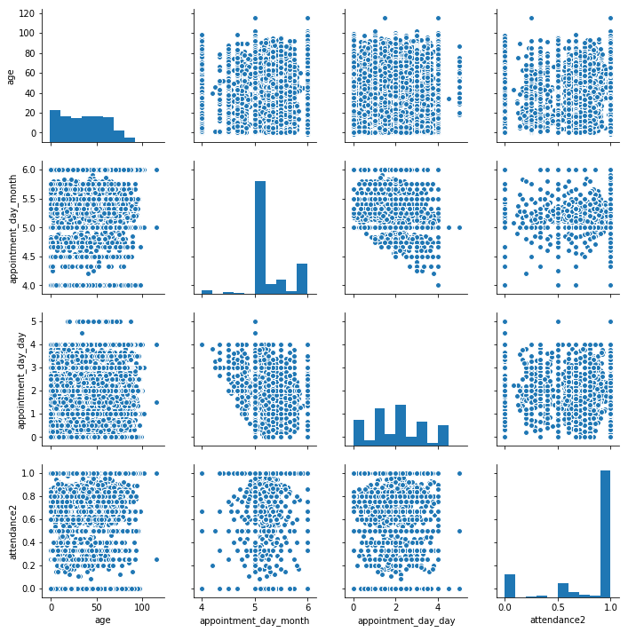

```python
# Are there correlations between numerical variables?
# Select variables of interest:
num_variables = ['age', 'appointment_day_month', 'appointment_day_day', 'attendance2']
# Plot all combinations:
sns.pairplot(data_patient[num_variables].mean())
plt.show();
```

**Is date associated with appointment attendance?**

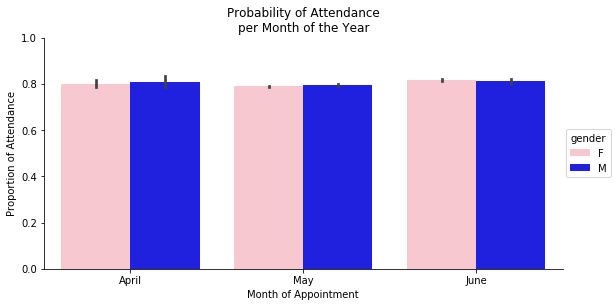

```python
# Probability of attendance per month (within gender)
# Create Seaborn figure:
fig = sns.factorplot(data=data, x='appointment_day_month', y='attendance2', hue='gender',
                    kind='bar', palette=['pink', 'blue'], size=4, aspect=2)
# Set figure configurations:
fig.set_axis_labels('Month of Appointment', 'Proportion of Attendance')
plt.title('Probability of Attendance\nper Month of the Year')
fig.set(ylim=(0, 1))
fig.set(xticklabels=['April', 'May', 'June']);
```

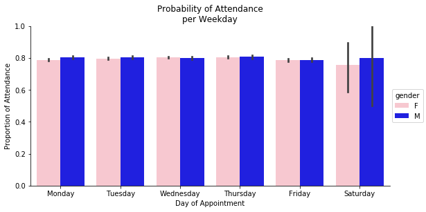

```python
# Probability of attendance per weekday
# Create Seaborn figure:
fig = sns.factorplot(data=data, x='appointment_day_day', y='attendance2', hue='gender',
                    kind='bar', palette=['pink', 'blue'], size=4, aspect=2)
# Set figure configurations:
fig.set_axis_labels('Day of Appointment', 'Proportion of Attendance')
plt.title('Probability of Attendance\nper Weekday')
fig.set(ylim=(0, 1))
fig.set(xticklabels=['Monday','Tuesday','Wednesday','Thursday','Friday','Saturday']);
```

**Is gender related to patient attendance to consultations?**

[figure not shown]

```python
# Histogram of total attendances per gender
fig = plt.figure(figsize=(12,4))

# Subplot 1: Men attendance
ax1 = fig.add_subplot(131)
ax1.hist(data_m['attendance'], color='blue')
plt.title('Histogram of\nTotal Attendance')
plt.xlabel('Attendance')
plt.ylabel('Frequency')
ax1.set_xlim(-0.5,1.5)
plt.text(0.5, 20000, 'Men', ha='center', va='center', size=20, color='blue')

# Subplot 2: Women attendance
ax2 = fig.add_subplot(132)
ax2.hist(data_m['attendance'], color='pink')
plt.title('Histogram of\nTotal Attendance')
plt.xlabel('Attendance')
plt.ylabel('Frequency')
ax2.set_xlim(-0.5,1.5)
plt.text(0.5, 20000, 'Women', ha='center', va='center', size=20, color='pink')

# Subplot 3: Probability of attendance per gender
ax3 = fig.add_subplot(133)
y_m = np.where(data_m['attendance']=='Yes', 1, 0).mean()
y_f = np.where(data_f['attendance']=='Yes', 1, 0).mean()
sd_m = np.where(data_m['attendance']=='Yes', 1, 0).std()
sd_f = np.where(data_f['attendance']=='Yes', 1, 0).std()

plt.errorbar(0, y_m, yerr=sd_m, color='blue', fmt='o')
plt.errorbar(1, y_f, yerr=sd_f, color='pink', fmt='o')
ax3.set_xlim(-0.5,1.5)
ax3.axes.get_xaxis().set_ticks([])
ax3.set_ylim(0,1)
plt.title('Probability of\nAttendance per Gender')
plt.xlabel('\nGender')
plt.ylabel('Probability of Attendance')
plt.text(0, 0.1, 'Men', ha='center', va='center', size=20, color='blue')
plt.text(1, 0.1, 'Women', ha='center', va='center', size=20, color='pink')

plt.tight_layout();
```

**Is patient health condition related to appointment attendance?**

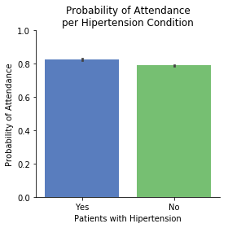

```python
# Hipertension condition is associated with no-shows (less attendance)?
# Plot figure:
fig = sns.factorplot(data=data, x='hipertension', y='attendance2', kind='bar', palette='muted')
# Set figure configurations:
fig.set(ylim=(0, 1))
plt.title('Probability of Attendance\nper Hipertension Condition')
plt.xlabel('Patients with Hipertension')
plt.ylabel('Probability of Attendance')

plt.tight_layout()
plt.show();
```

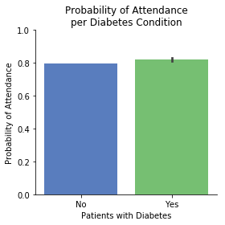

```python
# Diabetes condition is associated with no-shows (less attendance)?
# Plot figure:
fig = sns.factorplot(data=data, x='diabetes', y='attendance2', kind='bar', palette='muted')
# Set figure configurations:
fig.set(ylim=(0, 1))
plt.title('Probability of Attendance\nper Diabetes Condition')
plt.xlabel('Patients with Diabetes')
plt.ylabel('Probability of Attendance')

plt.tight_layout()
plt.show();
```

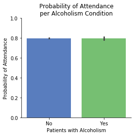

```python
# Alcoholism condition is associated with no-shows (less attendance)?
# Plot figure:
fig = sns.factorplot(data=data, x='alcoholism', y='attendance2', kind='bar', palette='muted')
# Set figure configurations:
fig.set(ylim=(0, 1))
plt.title('Probability of Attendance\nper Alcoholism Condition')
plt.xlabel('Patients with Alcoholism')
plt.ylabel('Probability of Attendance')

plt.tight_layout()
plt.show();
```

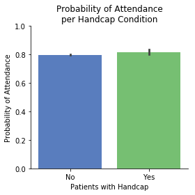

```python
# Handcap condition is associated with no-shows (less attendance)?
# Plot figure:
fig = sns.factorplot(data=data, x='handcap', y='attendance2', kind='bar', palette='muted')
# Set figure configurations:
fig.set(ylim=(0, 1))
plt.title('Probability of Attendance\nper Handcap Condition')
plt.xlabel('Patients with Handcap')
plt.ylabel('Probability of Attendance')

plt.tight_layout()
plt.show();
```

**Does social support help patients attend medical appointments more often?**

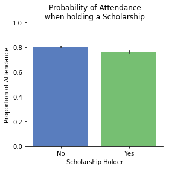

```python
# Plot figure:
fig = sns.factorplot(data=data, x='scholarship', y='attendance2', kind='bar', palette='muted')
# Set figure configurations:
fig.set_axis_labels('Scholarship Holder', 'Proportion of Attendance')
plt.title('Probability of Attendance\nwhen holding a Scholarship')
fig.set(ylim=(0, 1))

plt.tight_layout()
plt.show();
```

## Conclusions

Data suggests that patient attendance to consultations in Brazil might be related to some socio-demographic aspects of patients.

Concerning **date**, we cannot observe a strong pattern of month or weekday on appointment attendance. Suggesting that attendance to appointments is not related to specific months or days of the week. On Saturdays, there was a high variation in the proportion of attendances, nevertheless. This might be explained by the fact that on weekends, people are more inclined not to go to the doctor, producing more no-shows on this specific weekday.

In addition, when considering **gender**, men and women had similar attendance rates (80.27% and 80.4%, respectively). In other words, no-shows were approximately 20% of the total number of appointments scheduled. Men were in average younger than women (33+/-25 years old compared to 39+/-23 years old; mean +/- std), and from all successful appointments, men patients constituted only 35% compared to 65% of women.

When looking at the **social support** (if patients had scholarships), actually there seems to be a slight negative trend related to attendance. I.e., patients with scholarships came relatively fewer times to appointments compared to patients without scholarships. This difference was about 5.2% (rate of patients with scholarship was 0.77 against 0.81 on the other group). This difference is not so striking. No-show rate for scholarship holders was 0.23 (1-0.77), whereas for patients without social support was in average 0.19 (1-0.81).

Finally, it is still important to bare in mind that these analysis are descriptive and no statistical tests have been carried out. In other words, we cannot truly explain the behavior of patients regarding their attendance to medical consultations by only looking at these few variables represented in some graphical visualizations. Statistical tests should also be performed, perhaps including additional variables that were not covered here in order for us to make stronger interpretations about this dataset.